# Risk Factor Analysis

## Outcome Variable

**Outcome Variable:** stunted

## Predictor Variables

**Intervention Variable:** exclfeed3

**Adjustment Set:**

- arm
- sex
- brthmon
- W_mage
- meducyrs
- feducyrs
- hhwealth_quart
- hfoodsec
- W_mhtcm
- W_mwtkg
- W_mbmi
- vagbrth
- W_gagebrth
- W_birthwt
- W_birthlen
- W_nrooms
- W_nchldlt5
- month
- W_parity
- impfloor
- impsan
- safeh20
- delta_W_mage
- delta_meducyrs
- delta_feducyrs
- delta_hhwealth_quart
- delta_hfoodsec
- delta_W_mhtcm
- delta_W_mwtkg
- delta_W_mbmi
- delta_vagbrth
- delta_W_gagebrth
- delta_W_birthwt
- delta_W_birthlen
- delta_W_nrooms
- delta_W_nchldlt5
- delta_month
- delta_W_parity
- delta_impfloor
- delta_impsan
- delta_safeh20

## Stratifying Variables

The analysis was stratified on these variable(s):

- agecat
- studyid
- country

## Data Summary

| agecat | studyid | country | exclfeed3 | stunted | n_cell | n |
| --- | --- | --- | --- | --- | --- | --- |
| Birth | CMC-V-BCS-2002 | INDIA | 1 | 0 | 4 | 4 |
| Birth | CMC-V-BCS-2002 | INDIA | 1 | 1 | 0 | 4 |
| Birth | CMC-V-BCS-2002 | INDIA | 0 | 0 | 0 | 4 |
| Birth | CMC-V-BCS-2002 | INDIA | 0 | 1 | 0 | 4 |
| Birth | EE | PAKISTAN | 1 | 0 | 20 | 35 |
| Birth | EE | PAKISTAN | 1 | 1 | 15 | 35 |
| Birth | EE | PAKISTAN | 0 | 0 | 0 | 35 |
| Birth | EE | PAKISTAN | 0 | 1 | 0 | 35 |
| Birth | GMS-Nepal | NEPAL | 1 | 0 | 317 | 458 |
| Birth | GMS-Nepal | NEPAL | 1 | 1 | 63 | 458 |
| Birth | GMS-Nepal | NEPAL | 0 | 0 | 63 | 458 |
| Birth | GMS-Nepal | NEPAL | 0 | 1 | 15 | 458 |
| Birth | IRC | INDIA | 1 | 0 | 0 | 10 |
| Birth | IRC | INDIA | 1 | 1 | 0 | 10 |
| Birth | IRC | INDIA | 0 | 0 | 10 | 10 |
| Birth | IRC | INDIA | 0 | 1 | 0 | 10 |
| Birth | JiVitA-3 | BANGLADESH | 1 | 0 | 8076 | 13276 |
| Birth | JiVitA-3 | BANGLADESH | 1 | 1 | 3938 | 13276 |
| Birth | JiVitA-3 | BANGLADESH | 0 | 0 | 818 | 13276 |
| Birth | JiVitA-3 | BANGLADESH | 0 | 1 | 444 | 13276 |
| Birth | JiVitA-4 | BANGLADESH | 1 | 0 | 71 | 116 |
| Birth | JiVitA-4 | BANGLADESH | 1 | 1 | 34 | 116 |
| Birth | JiVitA-4 | BANGLADESH | 0 | 0 | 7 | 116 |
| Birth | JiVitA-4 | BANGLADESH | 0 | 1 | 4 | 116 |
| Birth | Keneba | GAMBIA | 1 | 0 | 1130 | 1356 |
| Birth | Keneba | GAMBIA | 1 | 1 | 68 | 1356 |
| Birth | Keneba | GAMBIA | 0 | 0 | 149 | 1356 |
| Birth | Keneba | GAMBIA | 0 | 1 | 9 | 1356 |
| Birth | MAL-ED | BANGLADESH | 1 | 0 | 112 | 215 |
| Birth | MAL-ED | BANGLADESH | 1 | 1 | 26 | 215 |

[output cut: 158 more lines]

The following strata were considered:

- agecat: 24 months, studyid: CMC-V-BCS-2002, country: INDIA
- agecat: 24 months, studyid: EE, country: PAKISTAN
- agecat: 24 months, studyid: GMS-Nepal, country: NEPAL
- agecat: 24 months, studyid: IRC, country: INDIA
- agecat: 24 months, studyid: JiVitA-3, country: BANGLADESH
- agecat: 24 months, studyid: JiVitA-4, country: BANGLADESH
- agecat: 24 months, studyid: Keneba, country: GAMBIA
- agecat: 24 months, studyid: MAL-ED, country: BANGLADESH
- agecat: 24 months, studyid: MAL-ED, country: BRAZIL
- agecat: 24 months, studyid: MAL-ED, country: INDIA
- agecat: 24 months, studyid: MAL-ED, country: NEPAL
- agecat: 24 months, studyid: MAL-ED, country: PERU
- agecat: 24 months, studyid: MAL-ED, country: SOUTH AFRICA
- agecat: 24 months, studyid: MAL-ED, country: TANZANIA, UNITED REPUBLIC OF
- agecat: 24 months, studyid: PROVIDE, country: BANGLADESH
- agecat: 6 months, studyid: CMC-V-BCS-2002, country: INDIA
- agecat: 6 months, studyid: EE, country: PAKISTAN
- agecat: 6 months, studyid: GMS-Nepal, country: NEPAL
- agecat: 6 months, studyid: IRC, country: INDIA
- agecat: 6 months, studyid: JiVitA-3, country: BANGLADESH
- agecat: 6 months, studyid: JiVitA-4, country: BANGLADESH
- agecat: 6 months, studyid: Keneba, country: GAMBIA
- agecat: 6 months, studyid: MAL-ED, country: BANGLADESH
- agecat: 6 months, studyid: MAL-ED, country: BRAZIL
- agecat: 6 months, studyid: MAL-ED, country: INDIA
- agecat: 6 months, studyid: MAL-ED, country: NEPAL
- agecat: 6 months, studyid: MAL-ED, country: PERU
- agecat: 6 months, studyid: MAL-ED, country: SOUTH AFRICA
- agecat: 6 months, studyid: MAL-ED, country: TANZANIA, UNITED REPUBLIC OF
- agecat: 6 months, studyid: PROVIDE, country: BANGLADESH
- agecat: 6 months, studyid: SAS-CompFeed, country: INDIA
- agecat: Birth, studyid: CMC-V-BCS-2002, country: INDIA
- agecat: Birth, studyid: EE, country: PAKISTAN
- agecat: Birth, studyid: GMS-Nepal, country: NEPAL
- agecat: Birth, studyid: IRC, country: INDIA
- agecat: Birth, studyid: JiVitA-3, country: BANGLADESH
- agecat: Birth, studyid: JiVitA-4, country: BANGLADESH
- agecat: Birth, studyid: Keneba, country: GAMBIA
- agecat: Birth, studyid: MAL-ED, country: BANGLADESH
- agecat: Birth, studyid: MAL-ED, country: BRAZIL
- agecat: Birth, studyid: MAL-ED, country: INDIA
- agecat: Birth, studyid: MAL-ED, country: NEPAL
- agecat: Birth, studyid: MAL-ED, country: PERU
- agecat: Birth, studyid: MAL-ED, country: SOUTH AFRICA
- agecat: Birth, studyid: MAL-ED, country: TANZANIA, UNITED REPUBLIC OF
- agecat: Birth, studyid: PROVIDE, country: BANGLADESH
- agecat: Birth, studyid: SAS-CompFeed, country: INDIA

### Dropped Strata

Some strata were dropped due to rare outcomes:

- agecat: Birth, studyid: CMC-V-BCS-2002, country: INDIA
- agecat: Birth, studyid: EE, country: PAKISTAN
- agecat: Birth, studyid: IRC, country: INDIA
- agecat: Birth, studyid: JiVitA-4, country: BANGLADESH
- agecat: Birth, studyid: MAL-ED, country: BRAZIL
- agecat: Birth, studyid: MAL-ED, country: INDIA
- agecat: Birth, studyid: MAL-ED, country: NEPAL
- agecat: Birth, studyid: MAL-ED, country: SOUTH AFRICA
- agecat: Birth, studyid: MAL-ED, country: TANZANIA, UNITED REPUBLIC OF
- agecat: 6 months, studyid: CMC-V-BCS-2002, country: INDIA
- agecat: 6 months, studyid: EE, country: PAKISTAN
- agecat: 6 months, studyid: IRC, country: INDIA
- agecat: 6 months, studyid: JiVitA-4, country: BANGLADESH
- agecat: 6 months, studyid: MAL-ED, country: BRAZIL
- agecat: 6 months, studyid: MAL-ED, country: NEPAL
- agecat: 6 months, studyid: MAL-ED, country: SOUTH AFRICA
- agecat: 24 months, studyid: CMC-V-BCS-2002, country: INDIA
- agecat: 24 months, studyid: EE, country: PAKISTAN
- agecat: 24 months, studyid: IRC, country: INDIA
- agecat: 24 months, studyid: MAL-ED, country: BRAZIL

## Methods Detail

We’re interested in the causal parameters $E[Y_a]$ for all values of $a \in \mathcal{A}$. These parameters represent the mean outcome if, possibly contrary to fact, we intervened to set all units to have $A=a$. Under the randomization and positivity assumptions, these are identified by the statistical parameters $\psi_a=E_W[E_{Y|A,W}(Y|A=a,W)]$. In addition, we’re interested in the mean of $Y$, $E[Y]$ under no intervention (the observed mean). We will estimate these parameters by using SuperLearner to fit the relevant likelihood factors – $E_{Y|A,W}(Y|A=a,W)$ and $p(A=a|W)$, and then updating our likelihood fit using a joint TMLE.

For unadjusted analyses ($W=\{\}$), initial likelihoods were estimated using Lrnr_glm to estimate the simple $E(Y|A)$ and Lrnr_mean to estimate $p(A)$. For adjusted analyses, a small library containing Lrnr_glmnet, Lrnr_xgboost, and Lrnr_mean was used.

Having estimated these parameters, we will then use the delta method to estimate relative risks and attributable risks relative to a prespecified baseline level of $A$.

# Results Detail

## Results Plots

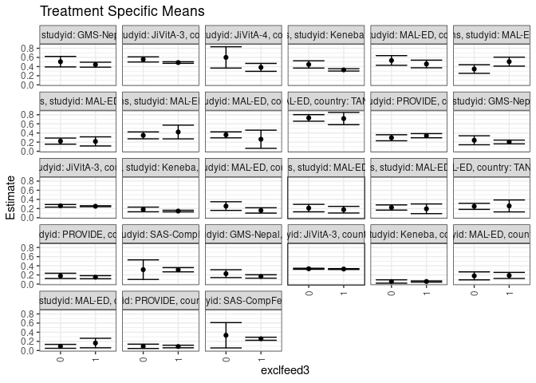

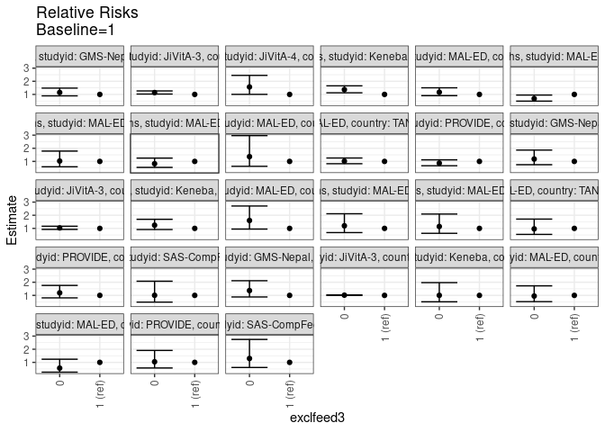

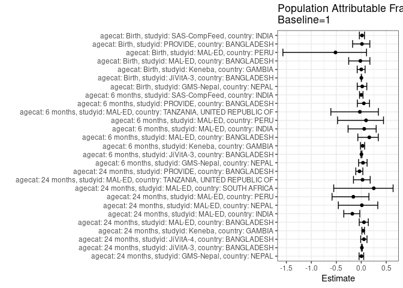

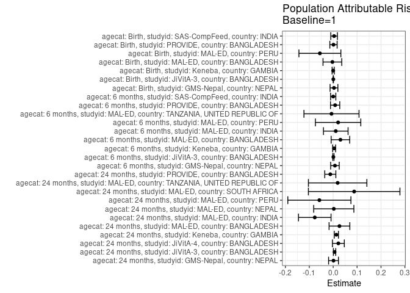

## Results Table

### Parameter: TSM

| agecat | studyid | country | intervention_level | baseline_level | estimate | ci_lower | ci_upper |
| --- | --- | --- | --- | --- | --- | --- | --- |
| Birth | GMS-Nepal | NEPAL | 1 | NA | 0.1670163 | 0.1295943 | 0.2044384 |
| Birth | GMS-Nepal | NEPAL | 0 | NA | 0.2279334 | 0.1418046 | 0.3140621 |
| Birth | JiVitA-3 | BANGLADESH | 1 | NA | 0.3294936 | 0.3203440 | 0.3386431 |
| Birth | JiVitA-3 | BANGLADESH | 0 | NA | 0.3353245 | 0.3243525 | 0.3462966 |
| Birth | Keneba | GAMBIA | 1 | NA | 0.0567613 | 0.0436539 | 0.0698687 |
| Birth | Keneba | GAMBIA | 0 | NA | 0.0569620 | 0.0208096 | 0.0931144 |
| Birth | MAL-ED | BANGLADESH | 1 | NA | 0.1894005 | 0.1234302 | 0.2553708 |
| Birth | MAL-ED | BANGLADESH | 0 | NA | 0.1799165 | 0.0927320 | 0.2671010 |
| Birth | MAL-ED | PERU | 1 | NA | 0.1632653 | 0.0595443 | 0.2669863 |
| Birth | MAL-ED | PERU | 0 | NA | 0.0919540 | 0.0489223 | 0.1349857 |
| Birth | PROVIDE | BANGLADESH | 1 | NA | 0.0878380 | 0.0595128 | 0.1161632 |
| Birth | PROVIDE | BANGLADESH | 0 | NA | 0.0918560 | 0.0451030 | 0.1386089 |
| Birth | SAS-CompFeed | INDIA | 1 | NA | 0.2572254 | 0.2236819 | 0.2907690 |
| Birth | SAS-CompFeed | INDIA | 0 | NA | 0.3333333 | 0.0564891 | 0.6101775 |
| 6 months | GMS-Nepal | NEPAL | 1 | NA | 0.2035122 | 0.1623112 | 0.2447132 |
| 6 months | GMS-Nepal | NEPAL | 0 | NA | 0.2404568 | 0.1423267 | 0.3385869 |
| 6 months | JiVitA-3 | BANGLADESH | 1 | NA | 0.2500487 | 0.2392595 | 0.2608378 |
| 6 months | JiVitA-3 | BANGLADESH | 0 | NA | 0.2595965 | 0.2307918 | 0.2884012 |
| 6 months | Keneba | GAMBIA | 1 | NA | 0.1447434 | 0.1271674 | 0.1623194 |
| 6 months | Keneba | GAMBIA | 0 | NA | 0.1799427 | 0.1285731 | 0.2313122 |
| 6 months | MAL-ED | BANGLADESH | 1 | NA | 0.1585662 | 0.1002325 | 0.2168999 |
| 6 months | MAL-ED | BANGLADESH | 0 | NA | 0.2538853 | 0.1591210 | 0.3486495 |
| 6 months | MAL-ED | INDIA | 1 | NA | 0.1749654 | 0.1023789 | 0.2475518 |
| 6 months | MAL-ED | INDIA | 0 | NA | 0.2098564 | 0.1283232 | 0.2913896 |
| 6 months | MAL-ED | PERU | 1 | NA | 0.1942920 | 0.0883390 | 0.3002449 |
| 6 months | MAL-ED | PERU | 0 | NA | 0.2223740 | 0.1653699 | 0.2793781 |
| 6 months | MAL-ED | TANZANIA, UNITED REPUBLIC OF | 1 | NA | 0.2571429 | 0.1265938 | 0.3876921 |
| 6 months | MAL-ED | TANZANIA, UNITED REPUBLIC OF | 0 | NA | 0.2477388 | 0.1818949 | 0.3135827 |
| 6 months | PROVIDE | BANGLADESH | 1 | NA | 0.1508297 | 0.1170378 | 0.1846217 |
| 6 months | PROVIDE | BANGLADESH | 0 | NA | 0.1799678 | 0.1229902 | 0.2369455 |
| 6 months | SAS-CompFeed | INDIA | 1 | NA | 0.3139842 | 0.2679102 | 0.3600581 |
| 6 months | SAS-CompFeed | INDIA | 0 | NA | 0.3157895 | 0.1014523 | 0.5301266 |
| 24 months | GMS-Nepal | NEPAL | 1 | NA | 0.4413439 | 0.3872703 | 0.4954176 |
| 24 months | GMS-Nepal | NEPAL | 0 | NA | 0.5069697 | 0.3923922 | 0.6215472 |
| 24 months | JiVitA-3 | BANGLADESH | 1 | NA | 0.4880227 | 0.4704353 | 0.5056100 |
| 24 months | JiVitA-3 | BANGLADESH | 0 | NA | 0.5565073 | 0.5001659 | 0.6128487 |
| 24 months | JiVitA-4 | BANGLADESH | 1 | NA | 0.3823529 | 0.2957347 | 0.4689712 |
| 24 months | JiVitA-4 | BANGLADESH | 0 | NA | 0.6000000 | 0.3670443 | 0.8329557 |
| 24 months | Keneba | GAMBIA | 1 | NA | 0.3275654 | 0.3018151 | 0.3533157 |
| 24 months | Keneba | GAMBIA | 0 | NA | 0.4468498 | 0.3672963 | 0.5264034 |
| 24 months | MAL-ED | BANGLADESH | 1 | NA | 0.4567250 | 0.3734435 | 0.5400064 |
| 24 months | MAL-ED | BANGLADESH | 0 | NA | 0.5334610 | 0.4278493 | 0.6390727 |
| 24 months | MAL-ED | INDIA | 1 | NA | 0.5077645 | 0.4097256 | 0.6058035 |
| 24 months | MAL-ED | INDIA | 0 | NA | 0.3462230 | 0.2525391 | 0.4399068 |
| 24 months | MAL-ED | NEPAL | 1 | NA | 0.2156750 | 0.1159813 | 0.3153688 |
| 24 months | MAL-ED | NEPAL | 0 | NA | 0.2219807 | 0.1555432 | 0.2884183 |
| 24 months | MAL-ED | PERU | 1 | NA | 0.4214391 | 0.2713491 | 0.5715291 |
| 24 months | MAL-ED | PERU | 0 | NA | 0.3478745 | 0.2725641 | 0.4231849 |
| 24 months | MAL-ED | SOUTH AFRICA | 1 | NA | 0.2631579 | 0.0647216 | 0.4615942 |
| 24 months | MAL-ED | SOUTH AFRICA | 0 | NA | 0.3588517 | 0.2936789 | 0.4240244 |
| 24 months | MAL-ED | TANZANIA, UNITED REPUBLIC OF | 1 | NA | 0.7150734 | 0.5810489 | 0.8490979 |
| 24 months | MAL-ED | TANZANIA, UNITED REPUBLIC OF | 0 | NA | 0.7290857 | 0.6570106 | 0.8011607 |
| 24 months | PROVIDE | BANGLADESH | 1 | NA | 0.3407972 | 0.2949809 | 0.3866135 |
| 24 months | PROVIDE | BANGLADESH | 0 | NA | 0.2952460 | 0.2292313 | 0.3612607 |

### Parameter: E(Y)

| agecat | studyid | country | intervention_level | baseline_level | estimate | ci_lower | ci_upper |
| --- | --- | --- | --- | --- | --- | --- | --- |
| Birth | GMS-Nepal | NEPAL | NA | NA | 0.1703057 | 0.1358418 | 0.2047695 |
| Birth | JiVitA-3 | BANGLADESH | NA | NA | 0.3300693 | 0.3209240 | 0.3392146 |
| Birth | Keneba | GAMBIA | NA | NA | 0.0567847 | 0.0444621 | 0.0691072 |
| Birth | MAL-ED | BANGLADESH | NA | NA | 0.1860465 | 0.1339088 | 0.2381842 |
| Birth | MAL-ED | PERU | NA | NA | 0.1076233 | 0.0668572 | 0.1483894 |
| Birth | PROVIDE | BANGLADESH | NA | NA | 0.0890538 | 0.0649864 | 0.1131212 |
| Birth | SAS-CompFeed | INDIA | NA | NA | 0.2609890 | 0.2179233 | 0.3040547 |
| 6 months | GMS-Nepal | NEPAL | NA | NA | 0.2108844 | 0.1727677 | 0.2490010 |
| 6 months | JiVitA-3 | BANGLADESH | NA | NA | 0.2508576 | 0.2404565 | 0.2612588 |
| 6 months | Keneba | GAMBIA | NA | NA | 0.1486797 | 0.1319680 | 0.1653914 |
| 6 months | MAL-ED | BANGLADESH | NA | NA | 0.1888412 | 0.1384789 | 0.2392035 |
| 6 months | MAL-ED | INDIA | NA | NA | 0.1857143 | 0.1329930 | 0.2384356 |
| 6 months | MAL-ED | PERU | NA | NA | 0.2148148 | 0.1657364 | 0.2638932 |
| 6 months | MAL-ED | TANZANIA, UNITED REPUBLIC OF | NA | NA | 0.2500000 | 0.1915738 | 0.3084262 |
| 6 months | PROVIDE | BANGLADESH | NA | NA | 0.1589404 | 0.1297581 | 0.1881227 |
| 6 months | SAS-CompFeed | INDIA | NA | NA | 0.3140704 | 0.2712850 | 0.3568557 |
| 24 months | GMS-Nepal | NEPAL | NA | NA | 0.4427083 | 0.3929634 | 0.4924533 |
| 24 months | JiVitA-3 | BANGLADESH | NA | NA | 0.4938170 | 0.4765272 | 0.5111067 |
| 24 months | JiVitA-4 | BANGLADESH | NA | NA | 0.4039735 | 0.3218653 | 0.4860818 |
| 24 months | Keneba | GAMBIA | NA | NA | 0.3408451 | 0.3161830 | 0.3655071 |
| 24 months | MAL-ED | BANGLADESH | NA | NA | 0.4829268 | 0.4143544 | 0.5514993 |
| 24 months | MAL-ED | INDIA | NA | NA | 0.4306931 | 0.3622377 | 0.4991484 |
| 24 months | MAL-ED | NEPAL | NA | NA | 0.2181818 | 0.1634817 | 0.2728819 |
| 24 months | MAL-ED | PERU | NA | NA | 0.3636364 | 0.2964623 | 0.4308104 |
| 24 months | MAL-ED | SOUTH AFRICA | NA | NA | 0.3508772 | 0.2887937 | 0.4129607 |
| 24 months | MAL-ED | TANZANIA, UNITED REPUBLIC OF | NA | NA | 0.7336957 | 0.6696529 | 0.7977384 |
| 24 months | PROVIDE | BANGLADESH | NA | NA | 0.3287197 | 0.2903909 | 0.3670485 |

### Parameter: RR

| agecat | studyid | country | intervention_level | baseline_level | estimate | ci_lower | ci_upper |
| --- | --- | --- | --- | --- | --- | --- | --- |
| Birth | GMS-Nepal | NEPAL | 1 | 1 | 1.0000000 | 1.0000000 | 1.0000000 |
| Birth | GMS-Nepal | NEPAL | 0 | 1 | 1.3647370 | 0.8798151 | 2.1169300 |
| Birth | JiVitA-3 | BANGLADESH | 1 | 1 | 1.0000000 | 1.0000000 | 1.0000000 |
| Birth | JiVitA-3 | BANGLADESH | 0 | 1 | 1.0176968 | 0.9984513 | 1.0373132 |
| Birth | Keneba | GAMBIA | 1 | 1 | 1.0000000 | 1.0000000 | 1.0000000 |
| Birth | Keneba | GAMBIA | 0 | 1 | 1.0035369 | 0.5107633 | 1.9717278 |
| Birth | MAL-ED | BANGLADESH | 1 | 1 | 1.0000000 | 1.0000000 | 1.0000000 |
| Birth | MAL-ED | BANGLADESH | 0 | 1 | 0.9499264 | 0.5228723 | 1.7257755 |
| Birth | MAL-ED | PERU | 1 | 1 | 1.0000000 | 1.0000000 | 1.0000000 |
| Birth | MAL-ED | PERU | 0 | 1 | 0.5632184 | 0.2558581 | 1.2398080 |
| Birth | PROVIDE | BANGLADESH | 1 | 1 | 1.0000000 | 1.0000000 | 1.0000000 |
| Birth | PROVIDE | BANGLADESH | 0 | 1 | 1.0457423 | 0.5726771 | 1.9095875 |
| Birth | SAS-CompFeed | INDIA | 1 | 1 | 1.0000000 | 1.0000000 | 1.0000000 |
| Birth | SAS-CompFeed | INDIA | 0 | 1 | 1.2958801 | 0.6113712 | 2.7467853 |
| 6 months | GMS-Nepal | NEPAL | 1 | 1 | 1.0000000 | 1.0000000 | 1.0000000 |
| 6 months | GMS-Nepal | NEPAL | 0 | 1 | 1.1815351 | 0.7494676 | 1.8626892 |
| 6 months | JiVitA-3 | BANGLADESH | 1 | 1 | 1.0000000 | 1.0000000 | 1.0000000 |
| 6 months | JiVitA-3 | BANGLADESH | 0 | 1 | 1.0381839 | 0.9254910 | 1.1645989 |
| 6 months | Keneba | GAMBIA | 1 | 1 | 1.0000000 | 1.0000000 | 1.0000000 |
| 6 months | Keneba | GAMBIA | 0 | 1 | 1.2431838 | 0.9133566 | 1.6921166 |
| 6 months | MAL-ED | BANGLADESH | 1 | 1 | 1.0000000 | 1.0000000 | 1.0000000 |
| 6 months | MAL-ED | BANGLADESH | 0 | 1 | 1.6011313 | 0.9484118 | 2.7030678 |
| 6 months | MAL-ED | INDIA | 1 | 1 | 1.0000000 | 1.0000000 | 1.0000000 |
| 6 months | MAL-ED | INDIA | 0 | 1 | 1.1994169 | 0.6797149 | 2.1164766 |
| 6 months | MAL-ED | PERU | 1 | 1 | 1.0000000 | 1.0000000 | 1.0000000 |
| 6 months | MAL-ED | PERU | 0 | 1 | 1.1445353 | 0.6258012 | 2.0932543 |
| 6 months | MAL-ED | TANZANIA, UNITED REPUBLIC OF | 1 | 1 | 1.0000000 | 1.0000000 | 1.0000000 |
| 6 months | MAL-ED | TANZANIA, UNITED REPUBLIC OF | 0 | 1 | 0.9634284 | 0.5435056 | 1.7077914 |
| 6 months | PROVIDE | BANGLADESH | 1 | 1 | 1.0000000 | 1.0000000 | 1.0000000 |
| 6 months | PROVIDE | BANGLADESH | 0 | 1 | 1.1931855 | 0.8096621 | 1.7583777 |
| 6 months | SAS-CompFeed | INDIA | 1 | 1 | 1.0000000 | 1.0000000 | 1.0000000 |
| 6 months | SAS-CompFeed | INDIA | 0 | 1 | 1.0057497 | 0.4866253 | 2.0786680 |
| 24 months | GMS-Nepal | NEPAL | 1 | 1 | 1.0000000 | 1.0000000 | 1.0000000 |
| 24 months | GMS-Nepal | NEPAL | 0 | 1 | 1.1486953 | 0.8921911 | 1.4789444 |
| 24 months | JiVitA-3 | BANGLADESH | 1 | 1 | 1.0000000 | 1.0000000 | 1.0000000 |
| 24 months | JiVitA-3 | BANGLADESH | 0 | 1 | 1.1403309 | 1.0276703 | 1.2653421 |
| 24 months | JiVitA-4 | BANGLADESH | 1 | 1 | 1.0000000 | 1.0000000 | 1.0000000 |
| 24 months | JiVitA-4 | BANGLADESH | 0 | 1 | 1.5692308 | 1.0057767 | 2.4483420 |
| 24 months | Keneba | GAMBIA | 1 | 1 | 1.0000000 | 1.0000000 | 1.0000000 |
| 24 months | Keneba | GAMBIA | 0 | 1 | 1.3641546 | 1.1241737 | 1.6553651 |
| 24 months | MAL-ED | BANGLADESH | 1 | 1 | 1.0000000 | 1.0000000 | 1.0000000 |
| 24 months | MAL-ED | BANGLADESH | 0 | 1 | 1.1680137 | 0.9075070 | 1.5033007 |
| 24 months | MAL-ED | INDIA | 1 | 1 | 1.0000000 | 1.0000000 | 1.0000000 |
| 24 months | MAL-ED | INDIA | 0 | 1 | 0.6818573 | 0.4896179 | 0.9495759 |
| 24 months | MAL-ED | NEPAL | 1 | 1 | 1.0000000 | 1.0000000 | 1.0000000 |
| 24 months | MAL-ED | NEPAL | 0 | 1 | 1.0292370 | 0.5929264 | 1.7866107 |
| 24 months | MAL-ED | PERU | 1 | 1 | 1.0000000 | 1.0000000 | 1.0000000 |
| 24 months | MAL-ED | PERU | 0 | 1 | 0.8254442 | 0.5440546 | 1.2523708 |
| 24 months | MAL-ED | SOUTH AFRICA | 1 | 1 | 1.0000000 | 1.0000000 | 1.0000000 |
| 24 months | MAL-ED | SOUTH AFRICA | 0 | 1 | 1.3636364 | 0.6278426 | 2.9617362 |
| 24 months | MAL-ED | TANZANIA, UNITED REPUBLIC OF | 1 | 1 | 1.0000000 | 1.0000000 | 1.0000000 |
| 24 months | MAL-ED | TANZANIA, UNITED REPUBLIC OF | 0 | 1 | 1.0195956 | 0.8251267 | 1.2598976 |
| 24 months | PROVIDE | BANGLADESH | 1 | 1 | 1.0000000 | 1.0000000 | 1.0000000 |
| 24 months | PROVIDE | BANGLADESH | 0 | 1 | 0.8663393 | 0.6704658 | 1.1194362 |

### Parameter: PAR

| agecat | studyid | country | intervention_level | baseline_level | estimate | ci_lower | ci_upper |
| --- | --- | --- | --- | --- | --- | --- | --- |
| Birth | GMS-Nepal | NEPAL | 1 | NA | 0.0032893 | -0.0130238 | 0.0196025 |
| Birth | JiVitA-3 | BANGLADESH | 1 | NA | 0.0005757 | -0.0000302 | 0.0011816 |
| Birth | Keneba | GAMBIA | 1 | NA | 0.0000234 | -0.0044574 | 0.0045042 |
| Birth | MAL-ED | BANGLADESH | 1 | NA | -0.0033540 | -0.0425540 | 0.0358460 |
| Birth | MAL-ED | PERU | 1 | NA | -0.0556420 | -0.1433470 | 0.0320630 |
| Birth | PROVIDE | BANGLADESH | 1 | NA | 0.0012158 | -0.0140489 | 0.0164804 |
| Birth | SAS-CompFeed | INDIA | 1 | NA | 0.0037636 | -0.0100156 | 0.0175428 |
| 6 months | GMS-Nepal | NEPAL | 1 | NA | 0.0073722 | -0.0105146 | 0.0252589 |
| 6 months | JiVitA-3 | BANGLADESH | 1 | NA | 0.0008090 | -0.0017846 | 0.0034025 |
| 6 months | Keneba | GAMBIA | 1 | NA | 0.0039363 | -0.0022571 | 0.0101297 |
| 6 months | MAL-ED | BANGLADESH | 1 | NA | 0.0302750 | -0.0085236 | 0.0690736 |
| 6 months | MAL-ED | INDIA | 1 | NA | 0.0107489 | -0.0407525 | 0.0622504 |
| 6 months | MAL-ED | PERU | 1 | NA | 0.0205229 | -0.0744603 | 0.1155060 |
| 6 months | MAL-ED | TANZANIA, UNITED REPUBLIC OF | 1 | NA | -0.0071429 | -0.1223231 | 0.1080373 |
| 6 months | PROVIDE | BANGLADESH | 1 | NA | 0.0081107 | -0.0112438 | 0.0274652 |
| 6 months | SAS-CompFeed | INDIA | 1 | NA | 0.0000862 | -0.0108674 | 0.0110398 |
| 24 months | GMS-Nepal | NEPAL | 1 | NA | 0.0013644 | -0.0192613 | 0.0219901 |
| 24 months | JiVitA-3 | BANGLADESH | 1 | NA | 0.0057943 | 0.0008359 | 0.0107528 |
| 24 months | JiVitA-4 | BANGLADESH | 1 | NA | 0.0216206 | -0.0032699 | 0.0465111 |
| 24 months | Keneba | GAMBIA | 1 | NA | 0.0132797 | 0.0045414 | 0.0220179 |
| 24 months | MAL-ED | BANGLADESH | 1 | NA | 0.0262019 | -0.0171885 | 0.0695923 |
| 24 months | MAL-ED | INDIA | 1 | NA | -0.0770715 | -0.1451731 | -0.0089698 |
| 24 months | MAL-ED | NEPAL | 1 | NA | 0.0025068 | -0.0814993 | 0.0865129 |
| 24 months | MAL-ED | PERU | 1 | NA | -0.0578028 | -0.1898339 | 0.0742284 |
| 24 months | MAL-ED | SOUTH AFRICA | 1 | NA | 0.0877193 | -0.1037709 | 0.2792095 |
| 24 months | MAL-ED | TANZANIA, UNITED REPUBLIC OF | 1 | NA | 0.0186223 | -0.1036768 | 0.1409214 |
| 24 months | PROVIDE | BANGLADESH | 1 | NA | -0.0120775 | -0.0352427 | 0.0110878 |

### Parameter: PAF

| agecat | studyid | country | intervention_level | baseline_level | estimate | ci_lower | ci_upper |
| --- | --- | --- | --- | --- | --- | --- | --- |
| Birth | GMS-Nepal | NEPAL | 1 | NA | 0.0193143 | -0.0811902 | 0.1104762 |
| Birth | JiVitA-3 | BANGLADESH | 1 | NA | 0.0017443 | -0.0000924 | 0.0035776 |
| Birth | Keneba | GAMBIA | 1 | NA | 0.0004119 | -0.0816941 | 0.0762858 |
| Birth | MAL-ED | BANGLADESH | 1 | NA | -0.0180275 | -0.2520440 | 0.1722495 |
| Birth | MAL-ED | PERU | 1 | NA | -0.5170068 | -1.5702556 | 0.1046378 |
| Birth | PROVIDE | BANGLADESH | 1 | NA | 0.0136520 | -0.1735408 | 0.1709855 |
| Birth | SAS-CompFeed | INDIA | 1 | NA | 0.0144204 | -0.0378960 | 0.0640998 |
| 6 months | GMS-Nepal | NEPAL | 1 | NA | 0.0349584 | -0.0535744 | 0.1160517 |
| 6 months | JiVitA-3 | BANGLADESH | 1 | NA | 0.0032248 | -0.0071724 | 0.0135146 |
| 6 months | Keneba | GAMBIA | 1 | NA | 0.0264748 | -0.0160653 | 0.0672339 |
| 6 months | MAL-ED | BANGLADESH | 1 | NA | 0.1603200 | -0.0691936 | 0.3405661 |
| 6 months | MAL-ED | INDIA | 1 | NA | 0.0578788 | -0.2645593 | 0.2981015 |
| 6 months | MAL-ED | PERU | 1 | NA | 0.0955374 | -0.4747969 | 0.4453117 |
| 6 months | MAL-ED | TANZANIA, UNITED REPUBLIC OF | 1 | NA | -0.0285716 | -0.6095681 | 0.3427059 |
| 6 months | PROVIDE | BANGLADESH | 1 | NA | 0.0510297 | -0.0785148 | 0.1650141 |
| 6 months | SAS-CompFeed | INDIA | 1 | NA | 0.0002744 | -0.0352245 | 0.0345560 |
| 24 months | GMS-Nepal | NEPAL | 1 | NA | 0.0030820 | -0.0446193 | 0.0486050 |
| 24 months | JiVitA-3 | BANGLADESH | 1 | NA | 0.0117338 | 0.0016675 | 0.0216986 |
| 24 months | JiVitA-4 | BANGLADESH | 1 | NA | 0.0535198 | -0.0115565 | 0.1144095 |
| 24 months | Keneba | GAMBIA | 1 | NA | 0.0389611 | 0.0129642 | 0.0642732 |
| 24 months | MAL-ED | BANGLADESH | 1 | NA | 0.0542564 | -0.0408582 | 0.1406793 |
| 24 months | MAL-ED | INDIA | 1 | NA | -0.1789476 | -0.3500757 | -0.0295107 |
| 24 months | MAL-ED | NEPAL | 1 | NA | 0.0114894 | -0.4592509 | 0.3303734 |
| 24 months | MAL-ED | PERU | 1 | NA | -0.1589576 | -0.5856588 | 0.1529182 |
| 24 months | MAL-ED | SOUTH AFRICA | 1 | NA | 0.2500000 | -0.5519753 | 0.6375587 |
| 24 months | MAL-ED | TANZANIA, UNITED REPUBLIC OF | 1 | NA | 0.0253815 | -0.1562442 | 0.1784770 |
| 24 months | PROVIDE | BANGLADESH | 1 | NA | -0.0367410 | -0.1095605 | 0.0312995 |